# GLM para dados Categóricos

Ana Karolina Silva

## 1 Introdução

- São dados que representam categorias ou grupos, e não números contínuos.Cada observação pertence a uma categoria discreta — como “espécie”, “sexo”, “período”, “tratamento”, “presente/ausente”, etc.

Para exercitar a família de distribuição Multinomial, usei os dados da minha dissertação referente à classificação dos períodos hidrológicos.

- A intenção é testar apenas a relação dos períodos hidrológicos com a profundidade máxima e o volume de água, para avaliar se essas variáveis numéricas podem ser usadas para predizer/classificar o período.
- Adicionei os dados com um aquivo .csv no diretório `/Dados` da disciplina.

```r
#~~~~~~~~~~~~~~~~~~~~~~~~~~~~~~~~
# 1. Importando o banco de dados
#~~~~~~~~~~~~~~~~~~~~~~~~~~~~~~~~

dados <- read.table(file="../Dados/RELACAO_VAR_ABIOTICAS_RAZAO.csv", sep =";", header = T)
```

Visualizando informações contidas no banco de dados:

```r
#~~~~~~~~~~~~~~~~~~~~~~~~~~
# 2. Análise exploratória
#~~~~~~~~~~~~~~~~~~~~~~~~~~
str(dados)
```

```
## 'data.frame':    41 obs. of  24 variables:
##  $ ano                     : int  2010 2010 2010 2011 2011 2011 2011 2012 2012 2012 ...
##  $ meses                   : int  6 9 12 3 6 8 12 3 6 9 ...
##  $ volume                  : num  29544336 27959455 23227342 26374575 44421480 ...
##  $ volume_porc             : num  59.1 50.6 44.3 59 98.4 ...
##  $ precipitacao            : num  172.3 0 73.1 31 13.8 ...
##  $ zmax                    : num  14.6 17.2 18.5 17.5 17.7 19.3 19 18 18 19 ...
##  $ secchi                  : num  0.9 1.3 0.7 0.4 0.72 0.7 0.42 0.6 0.5 0.4 ...
##  $ zeu                     : num  2.7 3.9 2.1 1.2 2.16 2.1 1.26 1.8 1.5 1.2 ...
##  $ temperatura             : num  27.1 25.3 29.1 31 26.5 ...
##  $ condutividade           : int  340 803 850 746 798 711 683 812 864 916 ...
##  $ ph                      : num  10.6 8.81 8.9 9.08 7.88 8.37 8.92 8.77 8.82 8.87 ...
##  $ oxigenio_dissolvido     : num  10 7.66 11.21 14.28 13.31 ...
##  $ turbidez                : num  11 11.4 29.9 32.1 32.1 32.1 34.3 39.4 6.9 14.7 ...
##  $ solidos_suspensos_totais: num  8.29 24 21.43 35.6 3.6 ...
##  $ fosforo_total           : num  119.2 67.6 146.1 103.4 77.2 ...
##  $ ortofosfato             : num  15 10.3 0 0 51.6 ...
##  $ clorofila               : num  30.49 8.79 50.7 160.11 52.76 ...
##  $ razao_zoo_fito          : num  2704.4 4956 518.9 91.6 174.8 ...
##  $ biomassa_fito_total     : num  5.07 19.74 55.09 132.22 93.07 ...
##  $ biomassa_zoo_total      : num  13718 97832 28589 12109 16270 ...
##  $ periodo_volume          : chr  "cheia" "cheia" "cheia" "cheia" ...
##  $ classif_volume          : chr  "cheia" "cheia" "cheia" "cheia" ...
##  $ classif_kmeans          : chr  "transicao" "cheia" "cheia" "transicao" ...
##  $ tempo_num               : int  1 2 3 4 5 6 7 8 9 10 ...
```

- Explorando dados:

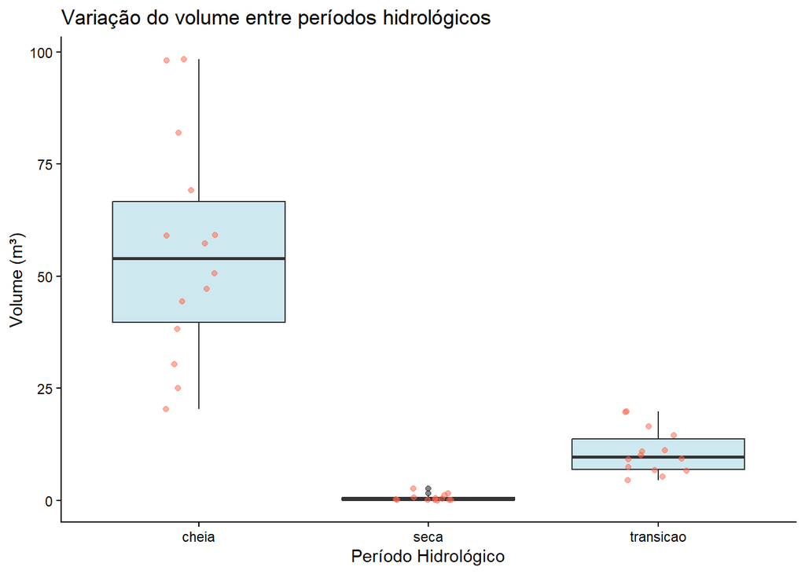

```r
#~~~~~~~~~~~~~~~~~~~~~~~~~~
# Volume de água ao longo dos períodos
#~~~~~~~~~~~~~~~~~~~~~~~~~~
library(ggplot2)
ggplot(dados, aes(x = classif_volume, y = volume_porc)) +
  geom_boxplot(fill = "lightblue", alpha = 0.6) +
  geom_jitter(width = 0.15, alpha = 0.5, color = "tomato") +
  labs(
    x = "Período Hidrológico",
    y = "Volume (m³)",
    title = "Variação do volume entre períodos hidrológicos"
  ) +
  theme_classic()
```

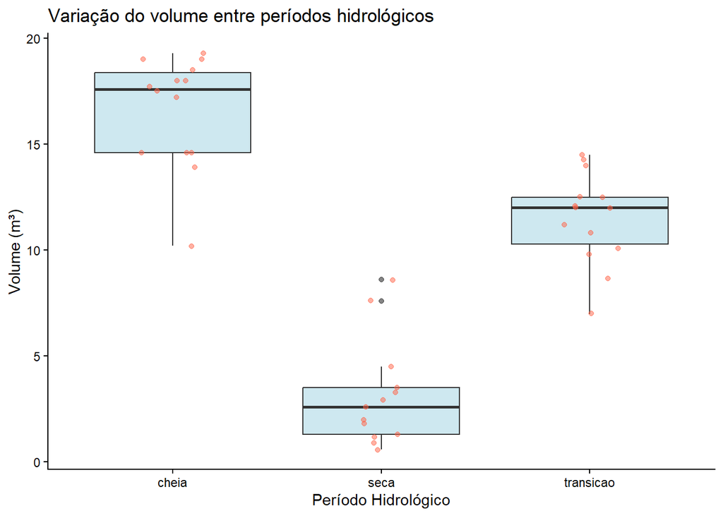

```r
#~~~~~~~~~~~~~~~~~~~~~~~~~~
# Profundidade máxima ao longo dos períodos
#~~~~~~~~~~~~~~~~~~~~~~~~~~
library(ggplot2)
ggplot(dados, aes(x = classif_volume, y = zmax)) +
  geom_boxplot(fill = "lightblue", alpha = 0.6) +
  geom_jitter(width = 0.15, alpha = 0.5, color = "tomato") +
  labs(
    x = "Período Hidrológico",
    y = "Volume (m³)",
    title = "Variação do volume entre períodos hidrológicos"
  ) +
  theme_classic()
```

- Tanto o volume de água quanto a profundidade máxima variou ao longo do períodos com consideráveis diferenças entre os 3 (cheia, seca e transição).

```r
#~~~~~~~~~~~~~~~~~~~~~~~~~~~~~~
# Teste de correlação
#~~~~~~~~~~~~~~~~~~~~~~~~~~~~~~
summary(aov(volume_porc ~ classif_volume, data = dados))
```

```
##                Df Sum Sq Mean Sq F value   Pr(>F)
## classif_volume  2  23538   11769   54.38 7.09e-12 ***
## Residuals      38   8225     216
## ---
## Signif. codes:  0 '***' 0.001 '**' 0.01 '*' 0.05 '.' 0.1 ' ' 1
```

```r
summary(aov(zmax ~ classif_volume, data = dados))
```

```
##                Df Sum Sq Mean Sq F value   Pr(>F)
## classif_volume  2 1236.3   618.2   105.6 3.04e-16 ***
## Residuals      38  222.5     5.9
## ---
## Signif. codes:  0 '***' 0.001 '**' 0.01 '*' 0.05 '.' 0.1 ' ' 1
```

- como os valores de p<0,05, observa-se que há alta colinearidade entre zmax e volume com os períodos.

## 2 Testando modelo Multinomial com os períodos hidrológicos como resposta

```r
#~~~~~~~~~~~~~~~~~~~~~~~~~~~~~~
# Carregando funções auxiliares
#~~~~~~~~~~~~~~~~~~~~~~~~~~~~~~
source("C:/Users/karol/Desktop/DISCIPLINA-MODELAGEM-2025/ECL0072-GLM_GAM-gh-pages/ECL0072-GLM_GAM-gh-pages/Scripts/funcoes_auxiliares.R")
```

```r
library(VGAM) #Modelo multinomial
library(nnet)

# definir o nível de referência
levels(dados$classif_volume) #cheia = 1
```

```r
#vglm roda o modelo multinomial
modelo1 <- vglm(classif_volume ~ volume_porc,
                family = multinomial(refLevel = 1),  # define a categoria de referência
                data = dados)

summary(modelo1)
```

```
##
## Call:
## vglm(formula = classif_volume ~ volume_porc, family = multinomial(refLevel = 1),
##     data = dados)
##
## Coefficients:
##               Estimate Std. Error z value Pr(>|z|)
## (Intercept):1  14.2494     6.6888    2.13   0.0331 *
## (Intercept):2  10.1848     6.4465      NA       NA
## volume_porc:1  -1.5231     0.5394      NA       NA
## volume_porc:2  -0.4768     0.3187      NA       NA
## ---
## Signif. codes:  0 '***' 0.001 '**' 0.01 '*' 0.05 '.' 0.1 ' ' 1
##
## Names of linear predictors: log(mu[,2]/mu[,1]), log(mu[,3]/mu[,1])
##
## Residual deviance: 6.7783 on 78 degrees of freedom
##
## Log-likelihood: -3.3892 on 78 degrees of freedom
##
## Number of Fisher scoring iterations: 13
##
## Warning: Hauck-Donner effect detected in the following estimate(s):
## '(Intercept):2', 'volume_porc:1', 'volume_porc:2'
##
##
## Reference group is level  1  of the response
```

Observações, o modelo não pode ser considerado:

Mas, o que podemos interpretar. Os coeficientes negativos de volume_porc:1 e volume_porc:2 indicam que, quanto maior o volume, menor a chance relativa de o período pertencer às classes 2 (seca) e 3 (transição) em comparação com a classe 1 (cheia).

## 3 Tentando modelo multinomial com período e razão zoo/fito

```r
library(VGAM) #Modelo multinomial
library(nnet)

# definir o nível de referência
levels(dados$classif_volume) #cheia = 1
```

```r
#vglm roda o modelo multinomial
modelo1 <- vglm(classif_volume ~ razao_zoo_fito,
                family = multinomial(refLevel = 1),  # define a categoria de referência
                data = dados)

summary(modelo1)
```

```
##
## Call:
## vglm(formula = classif_volume ~ razao_zoo_fito, family = multinomial(refLevel = 1),
##     data = dados)
##
## Coefficients:
##                    Estimate Std. Error z value Pr(>|z|)
## (Intercept):1    -1.0210811  0.5335418  -1.914   0.0556 .
## (Intercept):2    -0.5138142  0.4787960  -1.073   0.2832
## razao_zoo_fito:1  0.0002769  0.0001484   1.866   0.0620 .
## razao_zoo_fito:2  0.0002222  0.0001472   1.510   0.1311
## ---
## Signif. codes:  0 '***' 0.001 '**' 0.01 '*' 0.05 '.' 0.1 ' ' 1
##
## Names of linear predictors: log(mu[,2]/mu[,1]), log(mu[,3]/mu[,1])
##
## Residual deviance: 79.6025 on 78 degrees of freedom
##
## Log-likelihood: -39.8012 on 78 degrees of freedom
##
## Number of Fisher scoring iterations: 8
##
## No Hauck-Donner effect found in any of the estimates
##
##
## Reference group is level  1  of the response
```

- A razão zooplâncton/fitoplâncton (razao_zoo_fito) tem uma associação fraca a moderada com a variável classif_volume:

Apenas um dos coeficientes, classe 2 (seca) vs 1 (cheia) chega perto da significância estatística (p ≈ 0.062);

O coeficiente positivo sugere que, quanto maior a razão zoo/fito, maior a chance relativa de a observação estar na classe 2 (seca) comparada à 1 (cheia).

Ajuste do modelo é muito mais fraco do que com volume_porc:

Residual deviance: agora é 79.60 (vs 6.77 com volume_porc);

Log-likelihood: -39.80 (vs -3.39 com volume_porc), modelo menos informativo.

## 4 Conclusão

- Os 2 modelo realizados acima foram apenas testes com o modelo multinomial aprendido em sala, achei interessante e pensei em testar com essa linha de raciocionío apresentada :)